# Visualizing direct routes in the US through a single file import from Federal Aviation Administration prezipped coupon data

By Gadi Dreyfuss  
*Raw R file download available [HERE](https://gdrey.github.io/files/gis_4201c/gdrey.github.io/files/gis_4201c/Script.R)

# Project Info

This project impetus is as a component of a larger effort as part of my thesis exploring the economic impact of airlines to regional ‘spoke’ cities in the United States. As such, I intended for this project to be the precursor to more in depth data analysis to come— to explore data sources, process them analytically, and create the framework for the model and methodology I can continue develop throughout my thesis.

## Project Objective

Visualize non-stop flight connections in any quarter from prezipped, FAA data.

My data sources came primarily from the Federal Aviation Administration’s Data Profile: Airline Origin and Destination Survey (DB1B). Other data include .CSV files indicating the latitude and longitude of the referenced airports around the world.

See bottom of page for URLs.

# Project

Set origin target (enter your own, by default it is SWF)

Then set working directory.

```r
setwd("/Users/gdrey/Desktop/proj/wd")
```

```
The working directory was changed to /Users/gdrey/Desktop/proj/wd inside a notebook chunk. The working directory will be reset when the chunk is finished running. Use the knitr root.dir option in the setup chunk to change the working directory for notebook chunks.
```

Load libraries needed for project.

There is a conflict between tidyverse and dplyr packages. Implement this filter to address conflicts.

[output not shown]

## Convert .ZIP to .CSV

Because the quarter data is downloaded in a .zip file, it can be extracted to the folder. The only action required is to paste the pathname of the zip file and the desired location of the data.

## Load data

The first dataset is a .CSV of airports, their IATA Codes, and coordinates. The second dataset refers to the DB1B coupon data from FAA.

The first dataset can be downloaded here: gdrey.github.io/files/gis_4201c/data/airports.csv

The second dataset (and DB1B coupon data) can be found by navigating to:

https://www.transtats.bts.gov/DATABASES.ASP?Mode_ID=1&Mode_Desc=Aviation&Subject_ID2=0%20&pn=1 > Airline Origin and Destination Survey (DB1B) > DB1B Coupon Download (bottom right) > [select target quarter and year] > Prezipped file > Download

```r
airports <- read.csv("/Users/gdrey/Desktop/proj/data/airports.csv",stringsAsFactors = FALSE, header = TRUE)
coupon <- read_csv("/Users/gdrey/Desktop/proj/data/Origin_and_Destination_Survey_DB1BCoupon_2018_1.csv")
```

There are many columns, select only needed columns

```r
select_col_airports<-select(airports, "iata_code","latitude_deg","longitude_deg")
select_col_coupon<-select(coupon,"Year","Origin","Dest")
```

Based on previous visualization, remove outlier coordinates (PHL)

```r
select_col_airports<- select_col_airports[-c(38593), ]
```

Perform QC by checking to see if the selected columns made it in.

[output not shown]

```r
head(select_col_airports,5)

head(select_col_coupon,5)
```

| Year | Origin | Dest |
| --- | --- | --- |
| 2018 | DEN | MSO |
| 2018 | IAH | HNL |
| 2018 | MSY | IAH |
| 2018 | MSY | ORD |
| 2018 | DEN | FSD |

## Merge data

Merge the airport coordinate data and origin/destination data.

```r
merge_to_origin <- merge(select_col_coupon, select_col_airports, by.x = "Origin", by.y = "iata_code",all.x=TRUE)
route_data <- merge(merge_to_origin, select_col_airports, by.x = "Dest", by.y = "iata_code",all.x=TRUE)
```

Perform QC to see if route data appears merged, for extra QC, copy/paste coordinates of origin airport into https://www.google.com/maps

[output not shown]

Rename columns to make more sense.

Perform QC to ensure column names were changed

|  | Dest | Origin | Year | origin_lat | origin_long | dest_lat | dest_long |
| --- | --- | --- | --- | --- | --- | --- | --- |
| 1 | ABE | CLT | 2018 | 35.2140 | -80.9431 | 40.6521 | -75.4408 |
| 2 | ABE | ATL | 2018 | 33.6367 | -84.4281 | 40.6521 | -75.4408 |
| 3 | ABE | PHL | 2018 | 39.8719 | -75.2411 | 40.6521 | -75.4408 |
| 4 | ABE | PIE | 2018 | 27.9102 | -82.6874 | 40.6521 | -75.4408 |
| 5 | ABE | CLT | 2018 | 35.2140 | -80.9431 | 40.6521 | -75.4408 |

Select Target Origin from massive airport spreadsheet

Check and filter out missing data

[output not shown]

```r
Airport_origin_0[!complete.cases(Airport_origin_0),]

Airport_origin <- na.omit(Airport_origin_0)
```

## Create base visualization (map)

Basemap of contiguous US (can implement “World” to catch scope of Alaska and Hawaii on map)

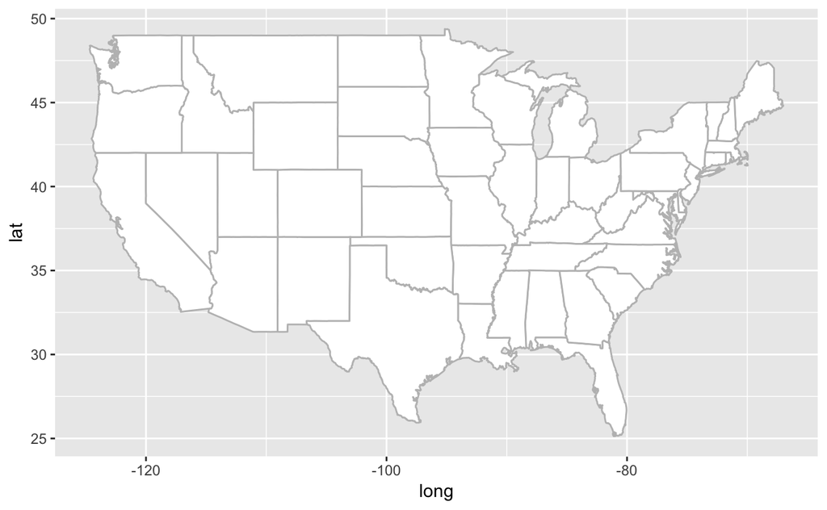

## Load the route data onto the basemap

```r
allUSA <- ggplot() + usMap +
  geom_curve(data=Airport_origin,
             aes(x=origin_long, y=origin_lat, xend=dest_long, yend=dest_lat),
             col="#00008b",
             size=.2,
             curvature=0.2) +
  geom_point(data=Airport_origin,
             aes(x=origin_long, y=origin_lat),
             colour="blue",
             size=1) +
  geom_point(data=Airport_origin,
             aes(x=dest_long, y=dest_lat),
             colour="blue") +
  theme(axis.line=element_blank(),
        axis.text.x=element_blank(),
        axis.text.y=element_blank(),
        axis.title.x=element_blank(),
        axis.title.y=element_blank(),
        axis.ticks=element_blank(),
        plot.title=element_text(hjust=0.5, size=12)) +
  ggtitle("United State Flight Route Map")
```

## View the map

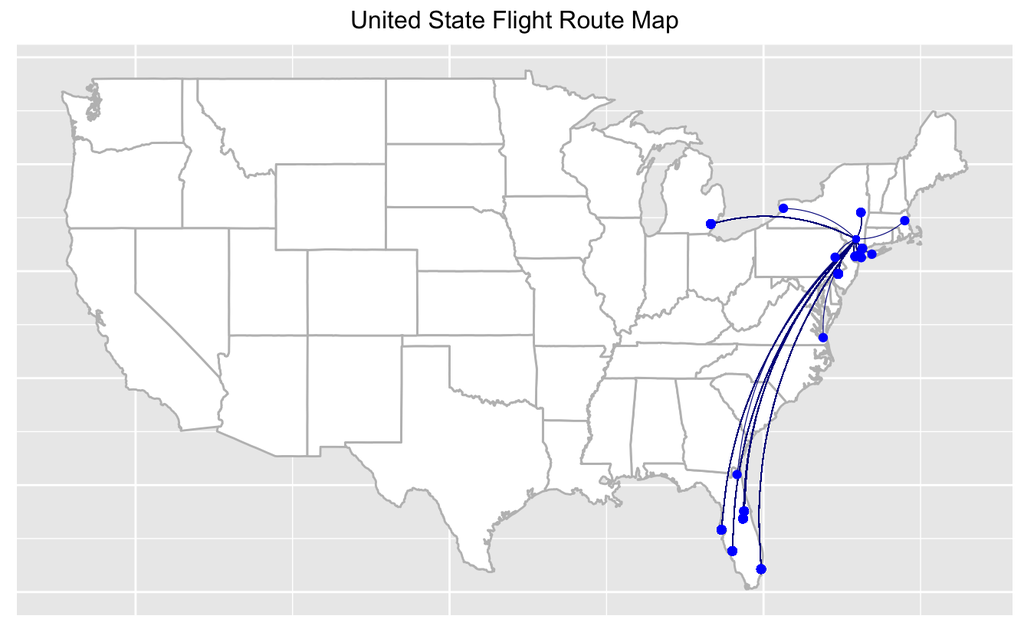